# Content-Based_Music_Recommendation_System

```python
import numpy as np
import pandas as pd
import seaborn as sns
import matplotlib.pyplot as plt
import plotly.express as px
import os
for dirname, _, filenames in os.walk('/kaggle/input'):
    for filename in filenames:
        print(os.path.join(dirname, filename))
%matplotlib inline
```

```python
!pip install kaggle
```

```python
import opendatasets
opendatasets.download('https://www.kaggle.com/datasets/yamaerenay/spotify-dataset-19212020-600k-tracks')
```

```
Please provide your Kaggle credentials to download this dataset. Learn more: http://bit.ly/kaggle-creds
Your Kaggle username:Your Kaggle Key:Downloading spotify-dataset-19212020-600k-tracks.zip to .\spotify-dataset-19212020-600k-tracks
```

# **Data Loading**

The dataset DF contains the following columns:

- '**name**': Name of the Song
- '**year**': Year of Release
- '**artists**': All the artists in the song
- '**id**': Unique id for each song
- '**popularity**': how popular was the song (range 0 to 100)
- '**valence**': range from 0 to 1
- '**acousticness**': range from 0 to 1
- '**danceability**': range from 0 to 1
- '**duration_ms**': duration of song in ms
- '**energy**': range from 0 to 1
- '**explicit**': 0-not explicit and 1-explict
- '**instrumentalness**': range from 0 to 1
- '**key**':All keys on octave encoded as values from 0 to 11, C as 0, C# as 1 and so on
- '**liveness**': range from 0 to 1
- '**loudness**': ranging from -60 to 0
- '**mode**': 0-Minor and 1-major
- '**speechiness**': range from 0 to 1
- '**tempo**': ranging from 50 to 150

```python
track = pd.read_csv('D:\Priyanka\BTech -Artificial Intelligence\Engg sem7\RS\project\moodbasedmusicrec\spotify-dataset-19212020-600k-tracks\Tracks.csv')
dataset = pd.read_csv('D:\Priyanka\BTech -Artificial Intelligence\Engg sem7\RS\project\moodbasedmusicrec\spotify-dataset-19212020-600k-tracks\data.csv')
genreby = pd.read_csv('D:\Priyanka\BTech -Artificial Intelligence\Engg sem7\RS\project\moodbasedmusicrec\spotify-dataset-19212020-600k-tracks\data_by_genres.csv')
yearby = pd.read_csv('D:\Priyanka\BTech -Artificial Intelligence\Engg sem7\RS\project\moodbasedmusicrec\spotify-dataset-19212020-600k-tracks\data_by_year.csv')
```

these are the following dataset we would be working with:

- **dataset** audio features of tracks, original data, 170k rows
- **track** audio features of tracks, 600k rows
- **yearby** audio features of years, derived from data_o.csv, 100 rows
- **genreby** audio features of genres, derived from databyartist_o.csv, 3k rows

```python
dataset.head()
```

|  | acousticness | artists | danceability | duration_ms | energy | explicit | id | instrumentalness | key | liveness | loudness | mode | name | popularity | release_date | speechiness | tempo | valence | year |
| --- | --- | --- | --- | --- | --- | --- | --- | --- | --- | --- | --- | --- | --- | --- | --- | --- | --- | --- | --- |
| 0 | 0.995 | ['Carl Woitschach'] | 0.708 | 158648 | 0.1950 | 0 | 6KbQ3uYMLKb5jDxLF7wYDD | 0.563 | 10 | 0.1510 | -12.428 | 1 | Singende Bataillone 1. Teil | 0 | 1928 | 0.0506 | 118.469 | 0.7790 | 1928 |
| 1 | 0.994 | ['Robert Schumann', 'Vladimir Horowitz'] | 0.379 | 282133 | 0.0135 | 0 | 6KuQTIu1KoTTkLXKrwlLPV | 0.901 | 8 | 0.0763 | -28.454 | 1 | Fantasiestücke, Op. 111: Più tosto lento | 0 | 1928 | 0.0462 | 83.972 | 0.0767 | 1928 |
| 2 | 0.604 | ['Seweryn Goszczyński'] | 0.749 | 104300 | 0.2200 | 0 | 6L63VW0PibdM1HDSBoqnoM | 0.000 | 5 | 0.1190 | -19.924 | 0 | Chapter 1.18 - Zamek kaniowski | 0 | 1928 | 0.9290 | 107.177 | 0.8800 | 1928 |
| 3 | 0.995 | ['Francisco Canaro'] | 0.781 | 180760 | 0.1300 | 0 | 6M94FkXd15sOAOQYRnWPN8 | 0.887 | 1 | 0.1110 | -14.734 | 0 | Bebamos Juntos - Instrumental (Remasterizado) | 0 | 1928-09-25 | 0.0926 | 108.003 | 0.7200 | 1928 |
| 4 | 0.990 | ['Frédéric Chopin', 'Vladimir Horowitz'] | 0.210 | 687733 | 0.2040 | 0 | 6N6tiFZ9vLTSOIxkj8qKrd | 0.908 | 11 | 0.0980 | -16.829 | 1 | Polonaise-Fantaisie in A-Flat Major, Op. 61 | 1 | 1928 | 0.0424 | 62.149 | 0.0693 | 1928 |

```python
dataset.columns
```

```
Index(['acousticness', 'artists', 'danceability', 'duration_ms', 'energy',
       'explicit', 'id', 'instrumentalness', 'key', 'liveness', 'loudness',
       'mode', 'name', 'popularity', 'release_date', 'speechiness', 'tempo',
       'valence', 'year'],
      dtype='object')
```

# **Exploratory Data Analysis**

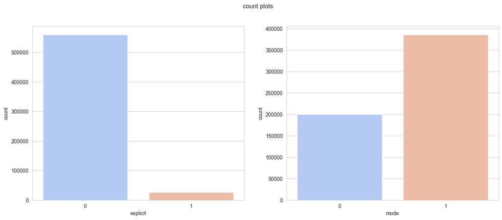

```python
fig, axes = plt.subplots(1, 2, figsize=(16, 6))

fig.suptitle('count plots')

sns.countplot(ax=axes[0],x='explicit',data=track,palette='coolwarm')
sns.countplot(ax=axes[1],x='mode',data=track,palette='coolwarm')
```

## **insights:**

> - from the count plots it is very clear that the number of **explict** songs are quiet few
> - and for the **mode** feature classification the major is almost double of minor

# **Various features & their change in trend with time**

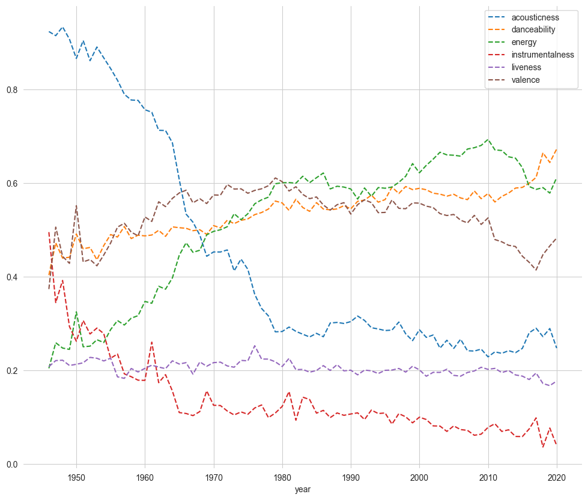

```python
zerotoone = yearby[['acousticness', 'danceability',
                    'energy', 'instrumentalness',
                    'liveness', 'valence','year']]
df = zerotoone.copy()
dfn = df[df.year > 1945]
dfn =dfn.reset_index(drop=True)
dfn.set_index('year',inplace=True)

sns.set_style('whitegrid')
dfn.plot(figsize=(12,10),style='--')
sns.despine(left = True,bottom=True)
```